# OCN683_homework_1

## Assess Residual plots

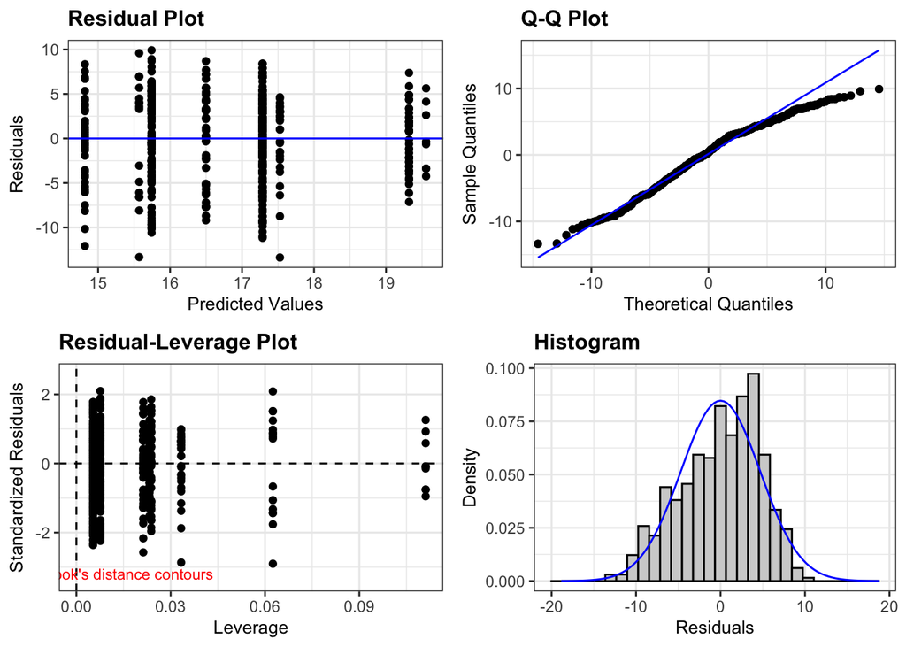

```r
#Residual plots
resid_panel(rat.species.model, plots = c('resid', 'qq', 'lev', 'hist'))
```

## Report F-Tests for the terms in the model

(note that if the model contains multiple predictors, these are partial residuals)

```r
#F stat
Anova <- Anova(rat.species.model)
Anova
```

```
## Anova Table (Type II tests)
##
## Response: foraging.ht.m
##                      Sum Sq  Df F value    Pr(>F)
## Rat_Removal           362.5   1 16.1081 6.903e-05 ***
## SPECIES               334.4   3  4.9528  0.002136 **
## Rat_Removal:SPECIES    32.1   3  0.4757  0.699318
## Residuals           11208.7 498
## ---
## Signif. codes:  0 '***' 0.001 '**' 0.01 '*' 0.05 '.' 0.1 ' ' 1
```

OK. I am unsure about F-tests at this point. Not only how to report them, but I am not sure yet what they are for and now to read them despite reading things all week. BUT I WILL LEARN. Would I do, uh, F 3,498 = 0.4, p = 0.699 showing that rat removal did not affect bird foraging height differently by species?

## Create an effects plot displaying the fitted effects

– magnitudes of the modeled relationships– look at the slope coefficent for linear regression.- I am confused by this hint.

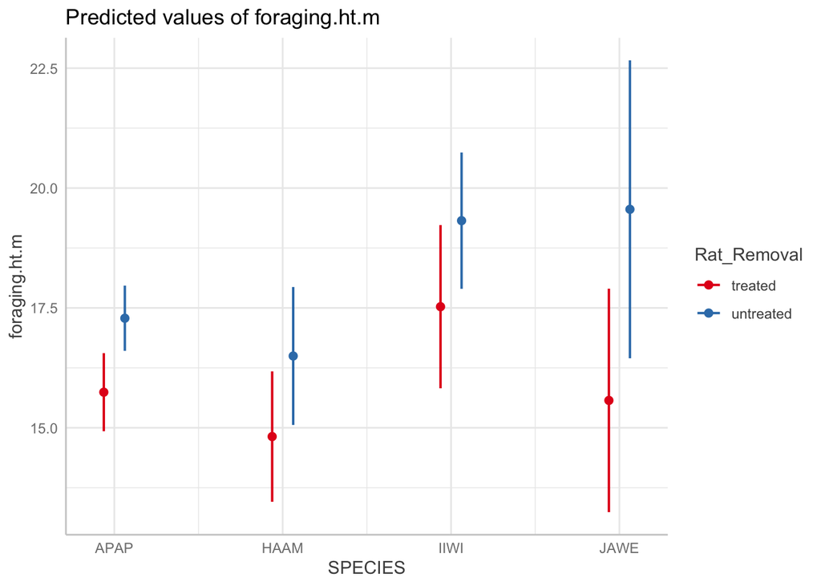

```r
#Effects Plot (?)
plot(ggeffect(rat.species.model, terms = c('SPECIES','Rat_Removal')))
```

## How do you interpret the results? What are the magnitudes of the effects?

AH. Okay. Er. No rat means bird go lower for food. The species have very slightly different foraging height ranges, but the rat removal didn’t affect one species more than others. I am not sure how to assess magnitude of the effects here yet.

# 4) Make a new model that adds kipuka area and arthopod biomass as predictors

## Kipuka area and arthopod biomass are both continuous predictors – before you add them to the model, make some scatterplots to assess whether these predictors should be transformed when including them in the model.

When assessing predictors for transformation, it doesn’t matter if the predictors are normally distributed (this only matters for the response variable) – *what matters is whether the predictors are very skewed,* such that a few outlying points will have a large influence on a fitted regression line. For skewed predictors, a log or square root transformation will generally help.

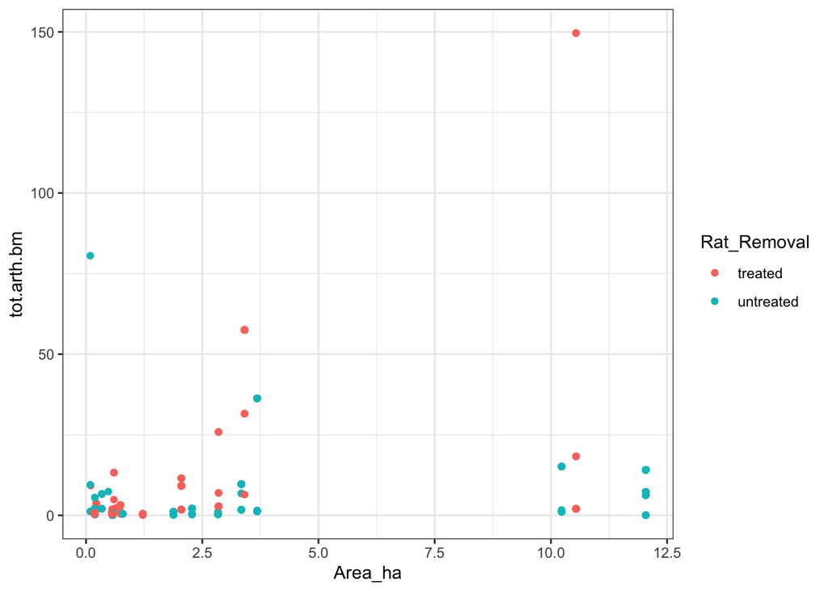

```r
#scatterplot showing raw predictors
scatter <- raw %>%
  ggplot(aes(x = Area_ha, y = tot.arth.bm, color = Rat_Removal))+
  geom_point()+
  theme_bw()
  scatter
```

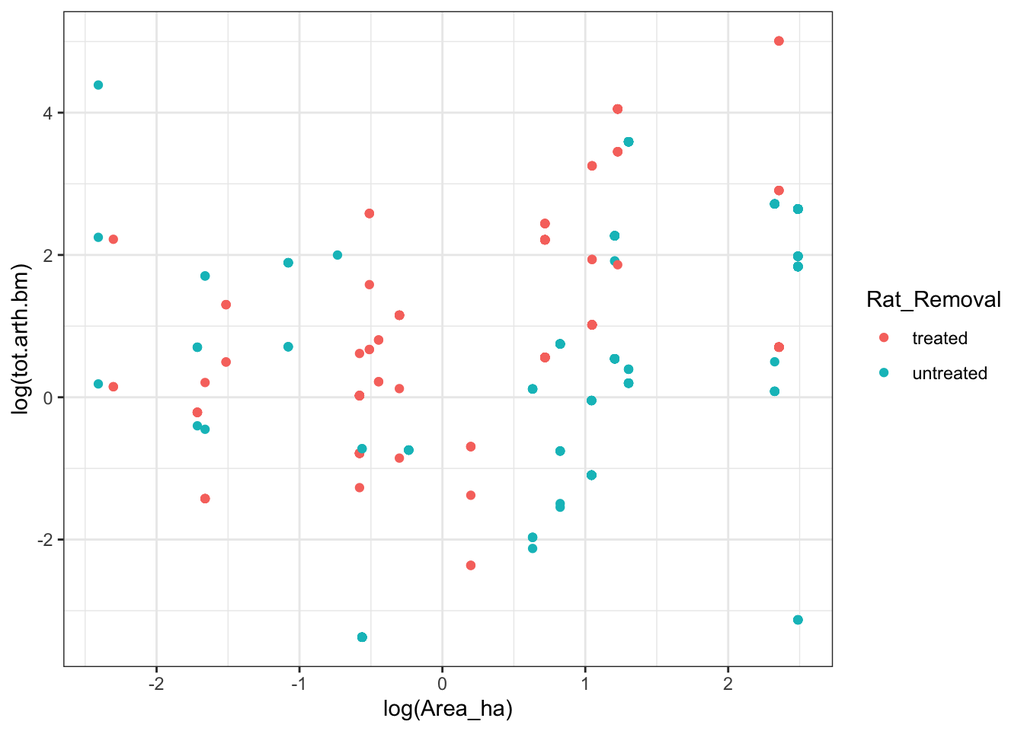

```r
#scatterplot showing log transformed predictors
scatterlog <- raw %>%
  ggplot(aes(x = log(Area_ha), y = log(tot.arth.bm), color = Rat_Removal))+
  geom_point()+
  theme_bw()
  scatterlog
```

That does look better! I think?

## Make a new model that adds kipuka area and arthopod biomass as predictors, and include interactions that test whether the treatment effect depends on these additional predictors.

So far we have examined the effect of the rat removal, but we have not considered the role of kipuka size, or the role of food availability (which is influenced in part by kipuka size).

```r
# Model
kipuka.model <- lm(foraging.ht.m ~ Rat_Removal * log(Area_ha) * log(tot.arth.bm), data = raw)
#Summary
summary(kipuka.model)
```

```
##
## Call:
## lm(formula = foraging.ht.m ~ Rat_Removal * log(Area_ha) * log(tot.arth.bm),
##     data = raw)
##
## Residuals:
##     Min      1Q  Median      3Q     Max
## -9.2866 -2.6786  0.0805  2.8046 10.7332
##
## Coefficients:
##                                                    Estimate Std. Error t value
## (Intercept)                                         14.2532     0.3281  43.438
## Rat_Removaluntreated                                -0.1286     0.4579  -0.281
## log(Area_ha)                                         2.9400     0.2332  12.610
## log(tot.arth.bm)                                     0.5740     0.2348   2.444
## Rat_Removaluntreated:log(Area_ha)                   -1.1591     0.3273  -3.542
## Rat_Removaluntreated:log(tot.arth.bm)               -0.6139     0.2780  -2.209
## log(Area_ha):log(tot.arth.bm)                       -0.8995     0.1763  -5.104
## Rat_Removaluntreated:log(Area_ha):log(tot.arth.bm)   1.3454     0.2005   6.709
##                                                    Pr(>|t|)
## (Intercept)                                         < 2e-16 ***
## Rat_Removaluntreated                               0.778888
## log(Area_ha)                                        < 2e-16 ***
## log(tot.arth.bm)                                   0.014865 *
## Rat_Removaluntreated:log(Area_ha)                  0.000435 ***
## Rat_Removaluntreated:log(tot.arth.bm)              0.027656 *
## log(Area_ha):log(tot.arth.bm)                      4.75e-07 ***
## Rat_Removaluntreated:log(Area_ha):log(tot.arth.bm) 5.32e-11 ***
## ---
## Signif. codes:  0 '***' 0.001 '**' 0.01 '*' 0.05 '.' 0.1 ' ' 1
##
## Residual standard error: 3.594 on 498 degrees of freedom
## Multiple R-squared:  0.4626, Adjusted R-squared:  0.455
## F-statistic: 61.24 on 7 and 498 DF,  p-value: < 2.2e-16
```

## Report F-tests and effects plots.

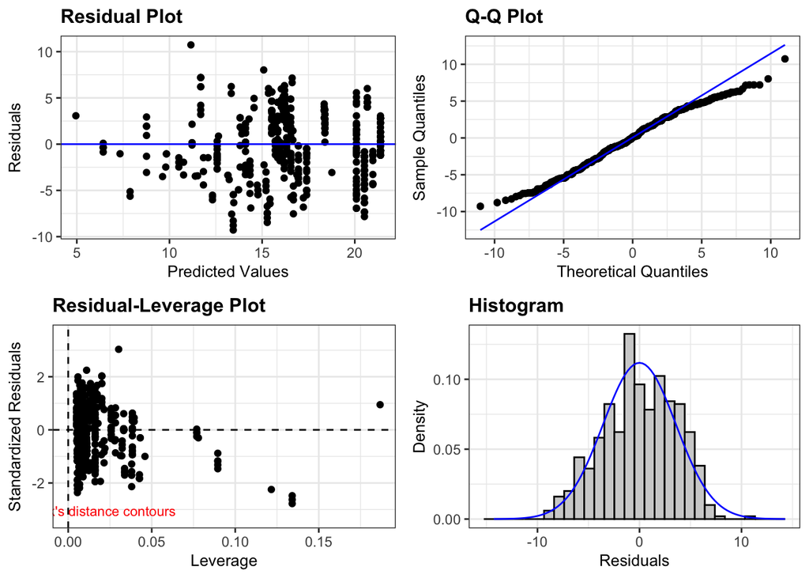

```r
#Residual plots
resid_panel(kipuka.model, plots = c('resid', 'qq', 'lev', 'hist'))
```

```r
#F test:
Anova(kipuka.model)
```

```
## Anova Table (Type II tests)
##
## Response: foraging.ht.m
##                                           Sum Sq  Df  F value    Pr(>F)
## Rat_Removal                                  9.9   1   0.7659   0.38191
## log(Area_ha)                              3287.0   1 254.4933 < 2.2e-16 ***
## log(tot.arth.bm)                            24.0   1   1.8590   0.17335
## Rat_Removal:log(Area_ha)                     7.7   1   0.5995   0.43913
## Rat_Removal:log(tot.arth.bm)                55.8   1   4.3234   0.03810 *
## log(Area_ha):log(tot.arth.bm)               35.8   1   2.7715   0.09659 .
## Rat_Removal:log(Area_ha):log(tot.arth.bm)  581.4   1  45.0168 5.325e-11 ***
## Residuals                                 6432.1 498
## ---
## Signif. codes:  0 '***' 0.001 '**' 0.01 '*' 0.05 '.' 0.1 ' ' 1
```

Right now, I think reporting this looks like F 1,498 = 45, p= 5x10^-11 that supports rat removal, area and biomass all influence foraging height? Do I report F tests for anythingn with a significant p value?

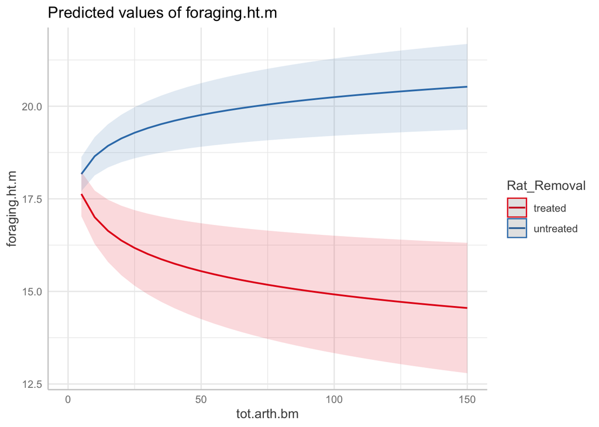

```r
#Effects Plot
plot(ggeffect(kipuka.model, terms = c('tot.arth.bm', 'Rat_Removal')))
```

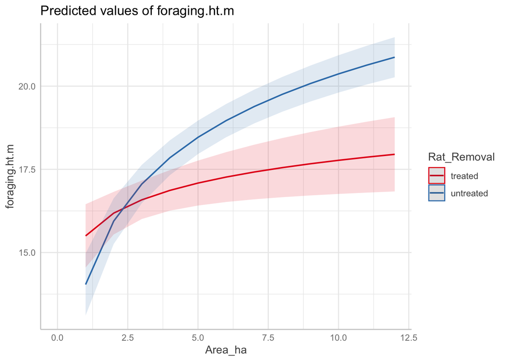

```r
plot(ggeffect(kipuka.model, terms = c('Area_ha', 'Rat_Removal')))
```

## How do the results of this model differ from the model in #3?

Did I do this right? Is any of this right? Is this on?

Er, I don’t think I did this correctly, but it does look like the more arthropod biomass you accumulate, there is a fairly large separation between foraging areas between treated and untreated plots. Treated plots mean that birds will trend to forage lower than birds in untreated plots. I don’t know if my effects plot is great since the scale seems kind of weird to me. Also, I may have done all of this very wrong.

## How do you interpret the results at this stage?

It looks like arthropod biomass and kipuka size effect the response variable in treatment groups.

# 5) Add DATE as a factor to the linear model from #4.

```r
date.model <- lm(foraging.ht.m ~ Rat_Removal * log(Area_ha) * log(tot.arth.bm) + DATE, data = raw)
#Summary
summary(date.model)
```

```
##
## Call:
## lm(formula = foraging.ht.m ~ Rat_Removal * log(Area_ha) * log(tot.arth.bm) +
##     DATE, data = raw)
##
## Residuals:
##     Min      1Q  Median      3Q     Max
## -7.4126 -1.6059  0.1957  1.7505  7.3839
##
## Coefficients:
##                                                     Estimate Std. Error t value
## (Intercept)                                         18.63270    0.63196  29.484
## Rat_Removaluntreated                                 0.52145    0.57267   0.911
## log(Area_ha)                                         3.60648    0.39435   9.145
## log(tot.arth.bm)                                    -0.20031    0.23301  -0.860
## DATE1/13/12                                         -0.05548    0.85049  -0.065
## DATE1/14/12                                         -7.54576    1.41222  -5.343
## DATE1/15/12                                         -8.11913    1.20742  -6.724
## DATE1/16/12                                         -3.02273    0.81724  -3.699
## DATE1/19/12                                         -2.00675    1.09679  -1.830
## DATE1/20/12                                         -5.84569    0.93354  -6.262
## DATE1/21/12                                         -3.08430    0.82413  -3.743
## DATE1/22/12                                         -8.07660    1.14192  -7.073
## DATE1/23/12                                         -3.58629    1.09218  -3.284
## DATE1/27/12                                         -7.03901    1.23838  -5.684
## DATE1/28/12                                         -7.61057    1.13373  -6.713
## DATE5/10/13                                         -8.58050    1.35369  -6.339
## DATE5/11/13                                         -8.74559    1.39694  -6.261
## DATE5/15/13                                         -9.12279    1.12606  -8.102
## DATE5/16/13                                         -3.76327    1.16784  -3.222
## DATE5/18/13                                         -6.84022    2.14174  -3.194
## DATE5/19/13                                         -6.29946    0.93761  -6.719
## DATE5/23/13                                         -1.79550    0.99731  -1.800
## DATE5/24/13                                         -4.50404    0.93898  -4.797
## DATE5/25/13                                        -11.65475    1.23351  -9.448
## DATE5/27/13                                         -5.67783    1.54543  -3.674
## DATE5/31/13                                         -4.79099    2.91908  -1.641
## DATE6/1/13                                          -2.28150    1.10680  -2.061
## DATE6/2/13                                          -7.20116    1.25046  -5.759
## DATE6/3/13                                          -6.83550    1.46457  -4.667
```

[output cut: 32 more lines]

```
## DATE6/1/13                                         0.039870 *
## DATE6/2/13                                         1.61e-08 ***
## DATE6/3/13                                         4.08e-06 ***
## DATE6/9/13                                         3.45e-05 ***
## Rat_Removaluntreated:log(Area_ha)                  0.019403 *
## Rat_Removaluntreated:log(tot.arth.bm)              0.083902 .
## log(Area_ha):log(tot.arth.bm)                      1.67e-05 ***
## Rat_Removaluntreated:log(Area_ha):log(tot.arth.bm) 3.24e-11 ***
## ---
## Signif. codes:  0 '***' 0.001 '**' 0.01 '*' 0.05 '.' 0.1 ' ' 1
##
## Residual standard error: 2.746 on 430 degrees of freedom
##   (42 observations deleted due to missingness)
## Multiple R-squared:  0.7064, Adjusted R-squared:  0.6839
## F-statistic: 31.36 on 33 and 430 DF,  p-value: < 2.2e-16
```

## How does the inclusion of the date of sampling alter the model results?

I am not confident enough I did the formula correctly to really make a good guess. I have a growth mindset and I will LEARN I SWEAR.

## Why do you think that is?

Date might parse out pseudo-replication. Stick a fork in me! I should have signed up for baby math.